# Prediction assignment

Jasmina

10 maj 2021

# Overview

Using devices such as Jawbone Up, Nike FuelBand, and Fitbit it is now possible to collect a large amount of data about personal activity relatively inexpensively.In this project we will use the data from accelerometers on the belt, forarm, arm and dumbell of 6 parcipants. The goal is to predict the manner in which the participants did the exercisse ("classe" variable). We can use any other variable to predict it with.

# Data loading and processing

Installing all the needed librarys

```r
library(caret)
library(dplyr)
```

```r
library(corrplot)
library(RColorBrewer)
library(rattle)
```

Loading the test and training dataset and looking at the variables, especially the classe variable

```r
training <- read.csv("pml-training.csv")
testing <- read.csv("pml-testing.csv")
str(training)
```

```
## 'data.frame':    19622 obs. of  160 variables:
##  $ X                       : int  1 2 3 4 5 6 7 8 9 10 ...
##  $ user_name               : Factor w/ 6 levels "adelmo","carlitos",..: 2 2 2 2 2 2 2 2 2 2 ...
##  $ raw_timestamp_part_1    : int  1323084231 1323084231 1323084231 1323084232 1323084232 1323084232 1323084232 1323084232 1323084232 1323084232 ...
##  $ raw_timestamp_part_2    : int  788290 808298 820366 120339 196328 304277 368296 440390 484323 484434 ...
##  $ cvtd_timestamp          : Factor w/ 20 levels "02/12/2011 13:32",..: 9 9 9 9 9 9 9 9 9 9 ...
##  $ new_window              : Factor w/ 2 levels "no","yes": 1 1 1 1 1 1 1 1 1 1 ...
##  $ num_window              : int  11 11 11 12 12 12 12 12 12 12 ...
##  $ roll_belt               : num  1.41 1.41 1.42 1.48 1.48 1.45 1.42 1.42 1.43 1.45 ...
##  $ pitch_belt              : num  8.07 8.07 8.07 8.05 8.07 8.06 8.09 8.13 8.16 8.17 ...
##  $ yaw_belt                : num  -94.4 -94.4 -94.4 -94.4 -94.4 -94.4 -94.4 -94.4 -94.4 -94.4 ...
##  $ total_accel_belt        : int  3 3 3 3 3 3 3 3 3 3 ...
##  $ kurtosis_roll_belt      : Factor w/ 397 levels "","-0.016850",..: 1 1 1 1 1 1 1 1 1 1 ...
##  $ kurtosis_picth_belt     : Factor w/ 317 levels "","-0.021887",..: 1 1 1 1 1 1 1 1 1 1 ...
##  $ kurtosis_yaw_belt       : Factor w/ 2 levels "","#DIV/0!": 1 1 1 1 1 1 1 1 1 1 ...
```

[output cut: 86 more lines]

```r
str(training$classe)
```

```
##  Factor w/ 5 levels "A","B","C","D",..: 1 1 1 1 1 1 1 1 1 1 ...
```

The classe variable is a 5 factor varible with levels A, B, C, D, E - which represent different activities.

## Cleaning the datasets

There are a lot of columns, with mostly NA values, we will not use them for our prediction. We will aslo not use the first 7 columns, because they more descriptive nature. Additionally there are many columns, which contain only a few values. We will remove them by using nearZeroVar (f.e: kurtosis_roll_belt)

```r
training <- training[, which(colMeans(!is.na(training))>0.9)]
training <- training[,-c(1:7)]
nzv <- nearZeroVar(training)
training <- training[,-nzv]
dim(training)
```

```
## [1] 19622    53
```

## Creating a validation dataset

```r
inTrain <- createDataPartition(training$classe, p=3/4, list=FALSE)
train <- training[inTrain,]
validate <- training[-inTrain,]
```

After the cleaning we are left with 53 variables We also look at a correlation plot

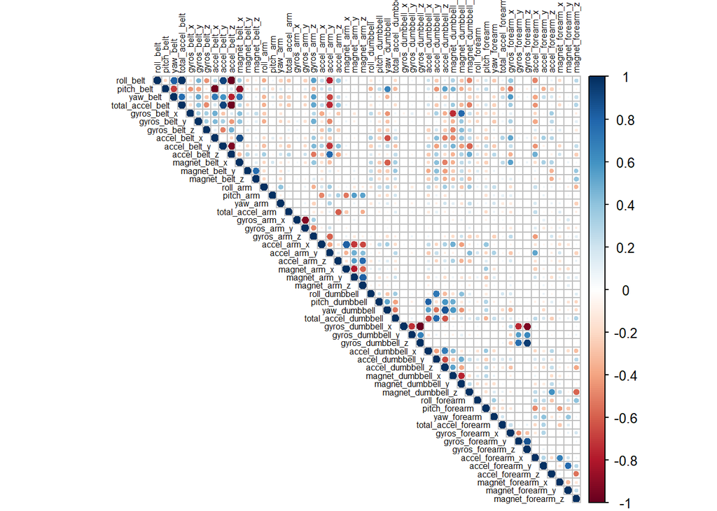

```r
corelation <- cor(train[,-53])
corrplot(corelation, method="circle", type = "upper", tl.cex=0.5, tl.col="black")
```

There are some variables that are highly correlated

# Model building

For this project we will try two different models - decision tree - random forests

## Decision trees

### Model

[figure not shown]

```r
dec_tree <- train(classe~., data=train, method="rpart")
fancyRpartPlot(dec_tree$finalModel)
```

### Prediction

```r
pred_dec <- predict(dec_tree, validate)
cmtree <- confusionMatrix(pred_dec, validate$classe)
cmtree
```

```
## Confusion Matrix and Statistics
##
##           Reference
## Prediction    A    B    C    D    E
##          A 1268  399  409  347  116
##          B   26  316   21  143  111
##          C  101  234  425  314  245
##          D    0    0    0    0    0
##          E    0    0    0    0  429
##
## Overall Statistics
##
##                Accuracy : 0.4971
##                  95% CI : (0.4831, 0.5112)
##     No Information Rate : 0.2845
##     P-Value [Acc > NIR] : < 2.2e-16
##
##                   Kappa : 0.343
##
##  Mcnemar's Test P-Value : NA
##
## Statistics by Class:
##
##                      Class: A Class: B Class: C Class: D Class: E
## Sensitivity            0.9090  0.33298  0.49708   0.0000  0.47614
## Specificity            0.6378  0.92389  0.77920   1.0000  1.00000
## Pos Pred Value         0.4994  0.51216  0.32221      NaN  1.00000
## Neg Pred Value         0.9463  0.85234  0.88006   0.8361  0.89453
## Prevalence             0.2845  0.19352  0.17435   0.1639  0.18373
## Detection Rate         0.2586  0.06444  0.08666   0.0000  0.08748
## Detection Prevalence   0.5177  0.12582  0.26896   0.0000  0.08748
## Balanced Accuracy      0.7734  0.62844  0.63814   0.5000  0.73807
```

We see that the accuracy rate of the model is low: 0.4971452 , and therefore out-of the sample error is about 0.5028548.

## Random forest

### Model

```r
control <- trainControl(method="cv", number=3, verboseIter = F)
ran_for <- train(classe~., data=train, method="rf", trControl=control, tuneLength = 5)
```

### Prediciton

```r
pred_rf <- predict(ran_for, validate)
cm_rf <- confusionMatrix(pred_rf, validate$classe)
cm_rf
```

```
## Confusion Matrix and Statistics
##
##           Reference
## Prediction    A    B    C    D    E
##          A 1395    4    0    0    0
##          B    0  945    1    0    0
##          C    0    0  852    5    5
##          D    0    0    2  799    2
##          E    0    0    0    0  894
##
## Overall Statistics
##
##                Accuracy : 0.9961
##                  95% CI : (0.994, 0.9977)
##     No Information Rate : 0.2845
##     P-Value [Acc > NIR] : < 2.2e-16
##
##                   Kappa : 0.9951
##
##  Mcnemar's Test P-Value : NA
##
## Statistics by Class:
##
##                      Class: A Class: B Class: C Class: D Class: E
## Sensitivity            1.0000   0.9958   0.9965   0.9938   0.9922
## Specificity            0.9989   0.9997   0.9975   0.9990   1.0000
## Pos Pred Value         0.9971   0.9989   0.9884   0.9950   1.0000
## Neg Pred Value         1.0000   0.9990   0.9993   0.9988   0.9983
## Prevalence             0.2845   0.1935   0.1743   0.1639   0.1837
## Detection Rate         0.2845   0.1927   0.1737   0.1629   0.1823
## Detection Prevalence   0.2853   0.1929   0.1758   0.1637   0.1823
## Balanced Accuracy      0.9994   0.9978   0.9970   0.9964   0.9961
```

We see that the accuracy rate of the model is high 0.9961256 , and therefore out-of the sample error is about 0.0038744.

# Applying the best model to the testing data.

```r
pred_test <- predict(ran_for, testing)
pred_test
```

```
##  [1] B A B A A E D B A A B C B A E E A B B B
## Levels: A B C D E
```